# Homework 3 Allen Zhu

# Lab Section

In this lab, we will go over regularization, classification and performance metrics. We will be using the caret package in R. https://topepo.github.io/caret/train-models-by-tag.html

# Perfomance Metrics

## K- fold cross validatation - Resampling method

Randomly split the training data into k folds. If you specify 10 folds, then you split the data into 10 partitions. Train the model on 9 of those partitions, and test your model on the 10th partition. Iterate through until every partition has been held out.

A smaller k is more biased, but a larger k can be very variable.

## Bootstrapping - Resampling method

Sample with replacement. Some samples may be represented several times within the boostrap sample, while others may not be represented at all. The samples that are not selected are called out of bag samples.

Boostrap error rates usually have less uncertainty than k-fold cross validation, but higher bias.

## Error

Deviation of the observed value to the true value (population mean)

## Residual

Deviation of the observed value to the estimated value (sample mean)
$$residual=y_i - \hat{y_i}$$
where $\hat{y_i}$ is the estimated value

## Mean Squared Error (MSE)

$$MSE=\frac{1}{n}\sum_{i=1}^{n}(y_i - \hat{y_i})^2$$

## Root Mean Squared Error (RMSE)

Same units as original data.

$$RMSE=\sqrt{MSE}$$

## R^2

Proportion of information explained by the model. It is a measure of correlation, not accuracy.
$$1-RSS/TSS$$

## L2 regularization : Ridge regression. Regularize by adding the sum of the coefficients, squared, to the function.

$$Ridge Regression=\sum_{i=1}^{n}(y_i - w_0 - \sum_{j=1}^{p}w_jx_{ij})^2 + \lambda\sum_{j=1}^p(w_j)^2$$

## L1 regularization : Lasso Regression. Regularize by adding the sum of the absolute value of the coefficients to the model. Coefficient estimates may be pushed to zero – Lasso can perform variable selection

$$Lasso Regression=\sum_{i=1}^{n}(y_i - w_0 - \sum_{j=1}^{p}w_jx_{ij})^2 + \lambda\sum_{j=1}^p|w_j|$$

## Sensitivity or True Positive Rate

TP = True Positives TN = True Negatives FP = False Positives - Type I error FN = False Negatives - Type II error N = actual negative samples P = actual positive samples

$$TPR=TP/(TP + FN)$$

## Specificity or True Negative Rate

$$TNR=TN/(TN + FP)$$

## Receiver Operating Characteristics (ROC)

Plot of True Positive Rate (sensitivity) against False Positive Rate, or plots the True Positive Rate (sensitivity) against specificity.

Either way, a good ROC curves up through the left corner, and has a large area underneath.

## Area under ROC curve (AUC)

The area underneath the ROC curve

## Logistic function:

$$P(X)=e^{w_0 + w_1X}/{1+e^{w_0+w_1X}}$$

### The broad steps of Machine learning in R.

1. Split the data into training and test. Set test aside.
2. Fit a good model to the training data. This includes using bootstapping, cross validation etc. to resample the training data and fit a good model.
3. Visualize if your model learned on the training data by looking at ROC curve and AUC.
4. Test how your model performs on the test data.

### Broad steps for choosing between models according to Max Kuhn and Kjell Johnson

1. Start with several models that are the least interpretable and the most flexible, like boosted trees and svms. These models are the often the most accurate.
2. Investigate simpler models that are less opaque, like partial least squares, generalized additive models, or naive bayes models.
3. Consider using the simplest model that reasonable approximates the performance of more complex models

## Ridge Regression

# Homework

## Lasso

$$Lasso Regression=\sum_{i=1}^{n}(y_i - w_0 - \sum_{j=1}^{p}w_jx_{ij})^2 + \lambda\sum_{j=1}^p|w_j|$$
2. Create and train model

```r
ctrl =  trainControl(method = "boot", 15)

Lasso_regression <- train(Temp ~ Wind + Month, data = train_regression,
                          method = 'lasso', trControl= ctrl)
```

Examine the residuals

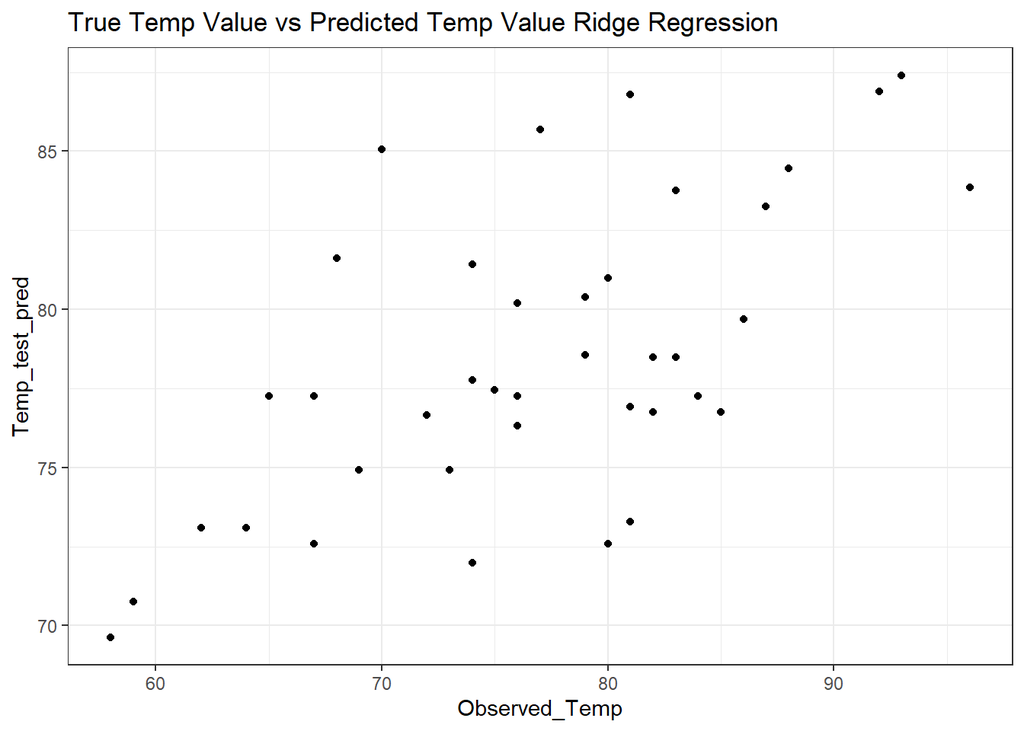

```r
lasso_test_pred <- predict(Lasso_regression, newdata = test_regression)

#plot the predicted values vs the observed values
plot_lasso_test_pred <- data.frame(Temp_test_pred = lasso_test_pred,
                                   Observed_Temp = test_regression$Temp)
ggplot(data = plot_lasso_test_pred) +
  geom_point(aes(x=Observed_Temp, y = Temp_test_pred)) +
  ggtitle("True Temp Value vs Predicted Temp Value Ridge Regression") +
  theme_bw()
```

```r
#median residual value should be close to zero
median(resid(Lasso_regression))
```

```
## [1] 0.07194436
```

# Classification

## Linear Discriminant analysis

- Good for well separated classes, more stable with small n than logistic regression, and good for more than 2 response classes.
- LDA assumes a normal distribution with a class specific mean and common variance.

```r
LDA <- lda(Species~ Sepal.Length + Sepal.Width + Petal.Length + Petal.Width,
           data= train_classifier, cv= T)
#cv  is cross validation
```

## Logistic Regression

$logodds_i=B_0 + B_1X_{i1}$

Here, the log odds represents the log odds of $Y_i$ being 0 or 1.

Where $logodds$ is the dependent variable, and $X_i$ is the independent variable. $B_{number}$ are the parameters to fit.

Logistic Regression assumes a linear relationship between the $logodds$ and $X$.

To convert from logodds, a not intuitive quantity, to odds, a more intuitive quantity, we use this non-linear equation:

$odds_i=e^{logodds_{i}}$ or $odds_i=e^{B_0 + B_1X_{i1}}$

Odds is defined as the probability that the event will occur divided by the probability that the event will not occur.

Now we convert from odds to probability.

The probability that an event will occur is the fraction of times you expect to see that event in many trials. Probabilities always range between 0 and 1.

To convert from odds to a probability, divide the odds by one plus the odds. So to convert odds of 1/9 to a probability, divide 1/9 by 10/9 to obtain the probability of 0.10

$P=odds/(odds+1)$

## Logistic Regression implementation

#Homework:

1. Use the Breast Cancer dataset from the mlbench package, and predict whether the cancer is malignant or benign using one of the algorithms we learned about in class. Give some rationale as to why you chose this algorithm. Plot ROC curves, and confusion matrices. If you are choosing a hyperparameter like K or lambda, explain how and why you chose it.

I selected a logistic regression to predict malignancy on the Breast Cancer dataset because it was testing between two classes: benign and malignant. Furthermore since the dependent variable is binary, we can then utilize the independent variables to make predictive analysis to make probability estimations.

```r
library(mlbench)
```

```r
data(BreastCancer)


str(BreastCancer)
```

```
## 'data.frame':    699 obs. of  11 variables:
##  $ Id             : chr  "1000025" "1002945" "1015425" "1016277" ...
##  $ Cl.thickness   : Ord.factor w/ 10 levels "1"<"2"<"3"<"4"<..: 5 5 3 6 4 8 1 2 2 4 ...
##  $ Cell.size      : Ord.factor w/ 10 levels "1"<"2"<"3"<"4"<..: 1 4 1 8 1 10 1 1 1 2 ...
##  $ Cell.shape     : Ord.factor w/ 10 levels "1"<"2"<"3"<"4"<..: 1 4 1 8 1 10 1 2 1 1 ...
##  $ Marg.adhesion  : Ord.factor w/ 10 levels "1"<"2"<"3"<"4"<..: 1 5 1 1 3 8 1 1 1 1 ...
##  $ Epith.c.size   : Ord.factor w/ 10 levels "1"<"2"<"3"<"4"<..: 2 7 2 3 2 7 2 2 2 2 ...
##  $ Bare.nuclei    : Factor w/ 10 levels "1","2","3","4",..: 1 10 2 4 1 10 10 1 1 1 ...
##  $ Bl.cromatin    : Factor w/ 10 levels "1","2","3","4",..: 3 3 3 3 3 9 3 3 1 2 ...
##  $ Normal.nucleoli: Factor w/ 10 levels "1","2","3","4",..: 1 2 1 7 1 7 1 1 1 1 ...
##  $ Mitoses        : Factor w/ 9 levels "1","2","3","4",..: 1 1 1 1 1 1 1 1 5 1 ...
##  $ Class          : Factor w/ 2 levels "benign","malignant": 1 1 1 1 1 2 1 1 1 1 ...
```

```r
# Train/Test set split

BC_size <- floor(0.75 * nrow(BreastCancer))
set.seed(15)
BC_pos <- sample(seq_len(nrow(BreastCancer)), size = BC_size)
train_classifier <- BreastCancer[BC_pos,]
test_classifier <- BreastCancer[-BC_pos,]

dim(train_classifier)
```

```
## [1] 524  11
```

```r
dim(test_classifier)
```

```
## [1] 175  11
```

```r
#Only 2 available.
train_classifier_log <- train_classifier[c(which(train_classifier$Class == "benign"),
                                           which(train_classifier$Class == "malignant")),]


test_classifier_log <- test_classifier[c(which(test_classifier$Class == "benign"),
                                         which(test_classifier$Class == "malignant")),]



ctrl <- trainControl(method = "repeatedcv", repeats = 15,classProbs = T,
                     savePredictions = T)

#Initially attempted to create a logistic regression model evaluating all the variables at once, and ended up with an error where my Pr(Z>|z|) values were all wonky, so I ran each variable separately


#Bare.nuclei had na values, so I created a 'cleaned' training dataset that omitted all the nas. The following set of logistic regressions were all done on this 'cleaned' data set to promote consistency.
train_clean <- na.omit(train_classifier_log)
test_clean <- na.omit(test_classifier_log)

dim(train_classifier_log)
```

```
## [1] 524  11
```

```r
dim(test_classifier_log)
```

```
## [1] 175  11
```

```r
dim(train_clean)
```

```
## [1] 510  11
```

```r
# After running into an error further down the code, where the predictor curves required numerical inputs. The three tested variables were coerced into a numeric format.


train_clean$Bare.nuclei <- as.numeric(as.character(train_clean$Bare.nuclei))
train_clean$Mitoses <- as.numeric(as.character(train_clean$Mitoses))
train_clean$Normal.nucleoli <- as.numeric(as.character(train_clean$Normal.nucleoli))



test_clean$Bare.nuclei <- as.numeric(as.character(test_clean$Bare.nuclei))
test_clean$Mitoses <- as.numeric(as.character(test_clean$Mitoses))
test_clean$Normal.nucleoli <- as.numeric(as.character(test_clean$Normal.nucleoli))
```

```r
# Individual logistic regressions for all the variables.

BC_THC <- train(Class ~ Cl.thickness, data = train_clean,
                             method = "glm", family= "binomial", trControl = ctrl)

summary(BC_THC)
```

```
##
## Call:
## NULL
##
## Deviance Residuals:
##      Min        1Q    Median        3Q       Max
## -2.32725  -0.54483  -0.13834   0.00013   3.05089
##
## Coefficients:
##                  Estimate Std. Error z value Pr(>|z|)
## (Intercept)         3.099    227.150   0.014    0.989
## Cl.thickness.L     21.437    924.075   0.023    0.981
## Cl.thickness.Q     10.021    613.025   0.016    0.987
## Cl.thickness.C      4.224    532.255   0.008    0.994
## `Cl.thickness^4`   -2.241    906.939  -0.002    0.998
## `Cl.thickness^5`   -3.399   1053.971  -0.003    0.997
## `Cl.thickness^6`   -4.920    890.130  -0.006    0.996
## `Cl.thickness^7`   -3.674    569.804  -0.006    0.995
## `Cl.thickness^8`   -2.284    270.570  -0.008    0.993
## `Cl.thickness^9`   -1.429     84.302  -0.017    0.986
##
## (Dispersion parameter for binomial family taken to be 1)
##
##     Null deviance: 655.96  on 509  degrees of freedom
## Residual deviance: 340.42  on 500  degrees of freedom
## AIC: 360.42
##
## Number of Fisher Scoring iterations: 17
```

```r
BC_CSize <- train(Class ~ Cell.size, data = train_clean,
                             method = "glm", family= "binomial", trControl = ctrl)
summary(BC_CSize)
```

```
##
## Call:
## NULL
##
## Deviance Residuals:
##      Min        1Q    Median        3Q       Max
## -2.32725  -0.14574  -0.14574   0.00008   3.01674
##
## Coefficients:
##               Estimate Std. Error z value Pr(>|z|)
## (Intercept)      7.611    451.723   0.017    0.987
## Cell.size.L     18.171   1057.029   0.017    0.986
## Cell.size.Q     -8.829   1432.053  -0.006    0.995
## Cell.size.C      2.882   1279.172   0.002    0.998
## `Cell.size^4`   12.912   1492.785   0.009    0.993
## `Cell.size^5`    5.526    797.828   0.007    0.994
## `Cell.size^6`   -1.133   1468.680  -0.001    0.999
## `Cell.size^7`   10.324   1716.038   0.006    0.995
## `Cell.size^8`   15.975   1313.753   0.012    0.990
## `Cell.size^9`    2.749   1966.667   0.001    0.999
##
## (Dispersion parameter for binomial family taken to be 1)
##
##     Null deviance: 655.96  on 509  degrees of freedom
## Residual deviance: 155.19  on 500  degrees of freedom
## AIC: 175.19
##
## Number of Fisher Scoring iterations: 18
```

```r
BC_CShape <- train(Class ~ Cell.shape, data = train_clean,
                             method = "glm", family= "binomial", trControl = ctrl)
summary(BC_CShape)
```

```
##
## Call:
## NULL
##
## Deviance Residuals:
##      Min        1Q    Median        3Q       Max
## -2.50419  -0.12356  -0.12356   0.00008   3.12378
##
## Coefficients:
##                  Estimate Std. Error z value Pr(>|z|)
## (Intercept)       6.04905  526.75184   0.011    0.991
## Cell.shape.L     26.16177 1990.03295   0.013    0.990
## Cell.shape.Q      6.09203 1166.78769   0.005    0.996
## Cell.shape.C     -0.09911 1348.64352   0.000    1.000
## `Cell.shape^4`   -6.13245 2037.37192  -0.003    0.998
## `Cell.shape^5`   -4.46923 2230.46091  -0.002    0.998
## `Cell.shape^6`    0.68278 2108.67633   0.000    1.000
## `Cell.shape^7`    4.81906 1712.61377   0.003    0.998
## `Cell.shape^8`    5.41049 1067.66388   0.005    0.996
## `Cell.shape^9`    1.86187  431.62776   0.004    0.997
##
## (Dispersion parameter for binomial family taken to be 1)
##
##     Null deviance: 655.96  on 509  degrees of freedom
## Residual deviance: 172.48  on 500  degrees of freedom
## AIC: 192.48
##
## Number of Fisher Scoring iterations: 18
```

```r
BC_MA <- train(Class ~ Marg.adhesion, data = train_clean,
                             method = "glm", family= "binomial", trControl = ctrl)
summary(BC_MA)
```

```
##
## Call:
## NULL
##
## Deviance Residuals:
##     Min       1Q   Median       3Q      Max
## -2.7253  -0.4008  -0.4008   0.2222   2.2635
##
## Coefficients:
##                     Estimate Std. Error z value Pr(>|z|)
## (Intercept)        5.764e+00  2.808e+02   0.021    0.984
## Marg.adhesion.L    1.761e+01  9.391e+02   0.019    0.985
## Marg.adhesion.Q   -3.925e+00  5.449e+02  -0.007    0.994
## Marg.adhesion.C   -1.210e+01  6.632e+02  -0.018    0.985
## `Marg.adhesion^4` -1.008e+01  9.803e+02  -0.010    0.992
## `Marg.adhesion^5` -6.192e-01  1.271e+03   0.000    1.000
## `Marg.adhesion^6`  3.166e+00  1.082e+03   0.003    0.998
## `Marg.adhesion^7` -8.798e-03  8.329e+02   0.000    1.000
## `Marg.adhesion^8` -4.700e+00  8.516e+02  -0.006    0.996
## `Marg.adhesion^9` -3.741e+00  5.582e+02  -0.007    0.995
##
## (Dispersion parameter for binomial family taken to be 1)
##
##     Null deviance: 655.96  on 509  degrees of freedom
## Residual deviance: 337.30  on 500  degrees of freedom
## AIC: 357.3
##
## Number of Fisher Scoring iterations: 16
```

```r
BC_ECC <- train(Class ~ Epith.c.size, data = train_clean,
                             method = "glm", family= "binomial", trControl = ctrl)
```

[output not shown]

[output cut: 34 more lines]

[output not shown]

```r
summary(BC_ECC)
```

```
##
## Call:
## NULL
##
## Deviance Residuals:
##     Min       1Q   Median       3Q      Max
## -2.6207  -0.3612  -0.3612   0.2982   2.6557
##
## Coefficients:
##                  Estimate Std. Error z value Pr(>|z|)
## (Intercept)        2.1927    88.2746   0.025    0.980
## Epith.c.size.L    10.3513   340.1549   0.030    0.976
## Epith.c.size.Q    -0.9363   153.6686  -0.006    0.995
## Epith.c.size.C    -0.3221   133.4220  -0.002    0.998
## `Epith.c.size^4`  -3.8275   363.1407  -0.011    0.992
## `Epith.c.size^5`  -6.7939   442.5024  -0.015    0.988
## `Epith.c.size^6`  -5.1314   377.9686  -0.014    0.989
## `Epith.c.size^7`  -4.3836   242.9130  -0.018    0.986
## `Epith.c.size^8`  -1.0174   115.5470  -0.009    0.993
## `Epith.c.size^9`   0.4374    36.0393   0.012    0.990
##
## (Dispersion parameter for binomial family taken to be 1)
##
##     Null deviance: 655.96  on 509  degrees of freedom
## Residual deviance: 303.64  on 500  degrees of freedom
## AIC: 323.64
##
## Number of Fisher Scoring iterations: 13
```

```r
BC_BN <- train(Class ~ Bare.nuclei, data = train_clean,
                             method = "glm", family= "binomial", trControl = ctrl)
summary(BC_BN)
```

```
##
## Call:
## NULL
##
## Deviance Residuals:
##     Min       1Q   Median       3Q      Max
## -2.9116  -0.3711  -0.3711   0.1705   2.3280
##
## Coefficients:
##             Estimate Std. Error z value Pr(>|z|)
## (Intercept) -3.40359    0.25302  -13.45   <2e-16 ***
## Bare.nuclei  0.76278    0.06844   11.14   <2e-16 ***
## ---
## Signif. codes:  0 '***' 0.001 '**' 0.01 '*' 0.05 '.' 0.1 ' ' 1
##
## (Dispersion parameter for binomial family taken to be 1)
##
##     Null deviance: 655.96  on 509  degrees of freedom
## Residual deviance: 264.97  on 508  degrees of freedom
## AIC: 268.97
##
## Number of Fisher Scoring iterations: 6
```

```r
BC_BC <- train(Class ~ Bl.cromatin, data = train_clean,
                             method = "glm", family= "binomial", trControl = ctrl)

BC_NN <- train(Class ~  Normal.nucleoli, data = train_clean,
                             method = "glm", family= "binomial", trControl = ctrl)
summary(BC_NN)
```

```
##
## Call:
## NULL
##
## Deviance Residuals:
##      Min        1Q    Median        3Q       Max
## -3.00322  -0.50219  -0.50219   0.09362   2.06547
##
## Coefficients:
##                 Estimate Std. Error z value Pr(>|z|)
## (Intercept)     -2.93635    0.22743  -12.91   <2e-16 ***
## Normal.nucleoli  0.92937    0.09731    9.55   <2e-16 ***
## ---
## Signif. codes:  0 '***' 0.001 '**' 0.01 '*' 0.05 '.' 0.1 ' ' 1
##
## (Dispersion parameter for binomial family taken to be 1)
##
##     Null deviance: 655.96  on 509  degrees of freedom
## Residual deviance: 360.57  on 508  degrees of freedom
## AIC: 364.57
##
## Number of Fisher Scoring iterations: 6
```

```r
BC_M <- train(Class ~  Mitoses, data = train_clean,
                             method = "glm", family= "binomial", trControl = ctrl)
summary(BC_M)
```

```
##
## Call:
## NULL
##
## Deviance Residuals:
##     Min       1Q   Median       3Q      Max
## -3.5741  -0.7806  -0.7806   0.7623   1.6352
##
## Coefficients:
##             Estimate Std. Error z value Pr(>|z|)
## (Intercept)  -2.0919     0.2346  -8.916  < 2e-16 ***
## Mitoses       1.0597     0.1771   5.983 2.19e-09 ***
## ---
## Signif. codes:  0 '***' 0.001 '**' 0.01 '*' 0.05 '.' 0.1 ' ' 1
##
## (Dispersion parameter for binomial family taken to be 1)
##
##     Null deviance: 655.96  on 509  degrees of freedom
## Residual deviance: 560.87  on 508  degrees of freedom
## AIC: 564.87
##
## Number of Fisher Scoring iterations: 6
```

```r
# After evaluating the logistic regressions, it seems that the variables that have a significant effect are Bare.nuclei, Normal.nucleoli, and Mitoses. A logistic regression was then run on just those three variables together. Unfortunately this resulted in a warning that stated the model reached reached what is assumed to be a perfect explanation, suggesting overfitting (the specific error is the following: glm.fit: fitted probabilities numerically 0 or 1 occurred). Any two of the three listed variables added together yielded the same result, so the three were tested separately to measure their effectiveness in predicting the cancer class.


# BC_Log <- train(Class ~ Bare.nuclei + Normal.nucleoli + Mitoses, data = train_clean,
                              # method = "glm", family= "binomial", trControl = ctrl)


# summary(BC_Log)
```

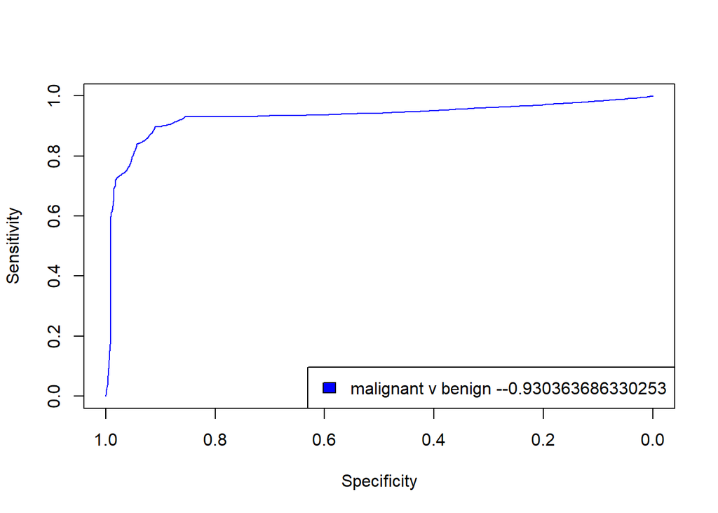

```r
# Roc Curve for Bare Nuclei

plot(x = roc(predictor = BC_BN$pred$malignant,
             response = BC_BN$pred$obs)$specificities,
     y = roc(predictor = BC_BN$pred$malignant,
             response = BC_BN$pred$obs)$sensitivities,
     col= "blue", xlim = c(1, 0), type ="l", ylab = "Sensitivity",
     xlab = "Specificity")
legend("bottomright", legend = paste("malignant v benign --",
                                     roc(predictor = BC_BN$pred$malignant,
                                         response = BC_BN$pred$obs)$auc
, sep = ""), col = c("blue"), fill = c("blue"))
```

```r
# Confusion matrix for bare nuclei and cancer malignancy


#predict cancer class using Bare Nuclei
BN_predict_class <- predict(BC_BN, newdata = test_clean)

#confusion matrix
confusionMatrix(BN_predict_class,
                reference = test_clean$Class)
```

```
## Confusion Matrix and Statistics
##
##            Reference
## Prediction  benign malignant
##   benign       109        15
##   malignant      0        49
##
##                Accuracy : 0.9133
##                  95% CI : (0.861, 0.9507)
##     No Information Rate : 0.6301
##     P-Value [Acc > NIR] : < 2.2e-16
##
##                   Kappa : 0.8045
##
##  Mcnemar's Test P-Value : 0.0003006
##
##             Sensitivity : 1.0000
##             Specificity : 0.7656
##          Pos Pred Value : 0.8790
##          Neg Pred Value : 1.0000
##              Prevalence : 0.6301
##          Detection Rate : 0.6301
##    Detection Prevalence : 0.7168
##       Balanced Accuracy : 0.8828
##
##        'Positive' Class : benign
##
```

```r
# Checking for correlation between log odds and bare nuclei

BN_predict <- predict(BC_BN, newdata = test_clean, type = "prob")

# To convert from a probability to odds, divide the probability by one minus that probability. So if the probability is 10% or 0.10 , then the odds are 0.1/0.9 or ‘1 to 9’

bnuclei <- BN_predict[,1] / (1 - BN_predict[,1])
log_bnuclei <- log(bnuclei)
cor.test(log_bnuclei, test_clean$Bare.nuclei)
```

```
##
##  Pearson's product-moment correlation
##
## data:  log_bnuclei and test_clean$Bare.nuclei
## t = -Inf, df = 171, p-value < 2.2e-16
## alternative hypothesis: true correlation is not equal to 0
## 95 percent confidence interval:
##  -1 -1
## sample estimates:
## cor
##  -1
```

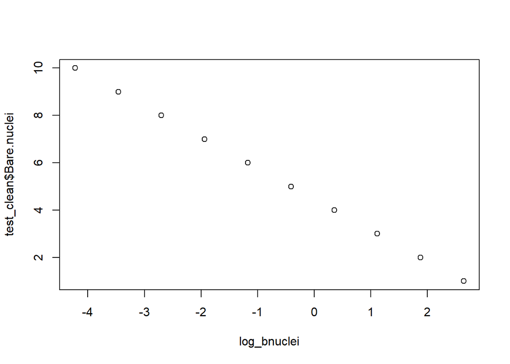

```r
plot(log_bnuclei, test_clean$Bare.nuclei)
```

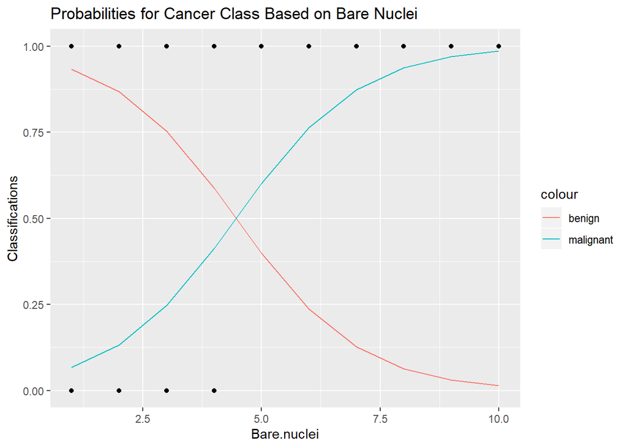

```r
# Create a new column in the data set where the classes were turned into numbers, and subtracted by 1, so that the probability plot can be made without actually changing the original class column

test_clean <- mutate(test_clean, Classifications = as.numeric(test_clean$Class) -1)

#Probability curve for bare nuclei predicting breast cancer malignancy.

BN_predict_prob <- predict(BC_BN, newdata = test_clean, type="prob")

Bare_nuclei_pred_prob_plot <- data.frame(Class_pred = BN_predict_prob, Bare.nuclei  = test_clean$Bare.nuclei)


ggplot(data = test_clean) +
  geom_point(aes(x=Bare.nuclei, y = Classifications)) +
  geom_line(data = Bare_nuclei_pred_prob_plot, aes(x = Bare.nuclei,
                                                y = Class_pred.benign, col =  "benign"))+
  geom_line(data = Bare_nuclei_pred_prob_plot, aes(x = Bare.nuclei,
                                                y = Class_pred.malignant, col = "malignant"))+
  ggtitle("Probabilities for Cancer Class Based on Bare Nuclei")
```

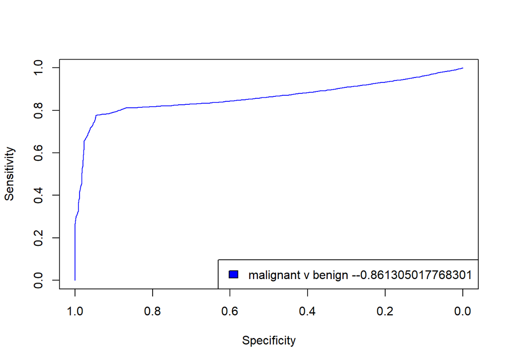

```r
#ROC Curve for normal nucleoli

plot(x = roc(predictor = BC_NN$pred$malignant,
             response = BC_NN$pred$obs)$specificities,
     y = roc(predictor = BC_NN$pred$malignant,
             response = BC_NN$pred$obs)$sensitivities,
     col= "blue", xlim = c(1, 0), type ="l", ylab = "Sensitivity",
     xlab = "Specificity")
legend("bottomright", legend = paste("malignant v benign --",
                                     roc(predictor = BC_NN$pred$malignant,
                                         response = BC_NN$pred$obs)$auc
, sep = ""), col = c("blue"), fill = c("blue"))
```

```r
#Confusion matrix for normal nucleoli on cancer malignancy

#predict iris species using Sepal legth
NN_predict_class <- predict(BC_NN, newdata = test_clean)

#confusion matrix
confusionMatrix(NN_predict_class,
                reference = test_clean$Class)
```

```
## Confusion Matrix and Statistics
##
##            Reference
## Prediction  benign malignant
##   benign       105        18
##   malignant      4        46
##
##                Accuracy : 0.8728
##                  95% CI : (0.8138, 0.9186)
##     No Information Rate : 0.6301
##     P-Value [Acc > NIR] : 8.067e-13
##
##                   Kappa : 0.7143
##
##  Mcnemar's Test P-Value : 0.005578
##
##             Sensitivity : 0.9633
##             Specificity : 0.7188
##          Pos Pred Value : 0.8537
##          Neg Pred Value : 0.9200
##              Prevalence : 0.6301
##          Detection Rate : 0.6069
##    Detection Prevalence : 0.7110
##       Balanced Accuracy : 0.8410
##
##        'Positive' Class : benign
##
```

```r
#Correlation check on log odds and normal nucleoli


NN_predict <- predict(BC_NN, newdata = test_clean, type = "prob")

# To convert from a probability to odds, divide the probability by one minus that probability. So if the probability is 10% or 0.10 , then the odds are 0.1/0.9 or ‘1 to 9’

Norm_nucleoli <- NN_predict[,1] / (1 - NN_predict[,1])
log_normnuc <- log(Norm_nucleoli)
cor.test(log_normnuc, test_clean$Normal.nucleoli)
```

```
##
##  Pearson's product-moment correlation
##
## data:  log_normnuc and test_clean$Normal.nucleoli
## t = -620530231, df = 171, p-value < 2.2e-16
## alternative hypothesis: true correlation is not equal to 0
## 95 percent confidence interval:
##  -1 -1
## sample estimates:
## cor
##  -1
```

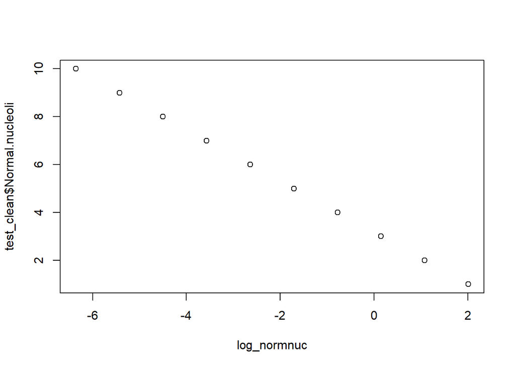

```r
plot(log_normnuc, test_clean$Normal.nucleoli)
```

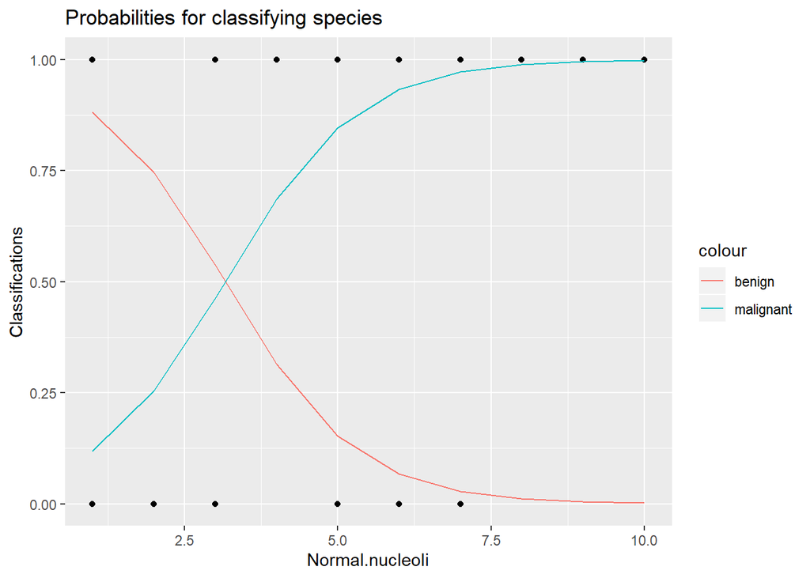

```r
# Probability plot for normal nucleoli and cancer malignancy

NN_predict_prob <- predict(BC_NN,  newdata = test_clean, type="prob")

Normal_nucleoli_pred_prob_plot <- data.frame(Class_pred = NN_predict_prob, Normal.nucleoli  = test_clean$Normal.nucleoli)


ggplot(data = test_clean) +
  geom_point(aes(x=Normal.nucleoli, y = Classifications)) +
  geom_line(data = Normal_nucleoli_pred_prob_plot, aes(x = Normal.nucleoli,
                                                y = Class_pred.benign, col =  "benign"))+
  geom_line(data = Normal_nucleoli_pred_prob_plot, aes(x = Normal.nucleoli,
                                                y = Class_pred.malignant, col = "malignant"))+
  ggtitle("Probabilities for classifying species")
```

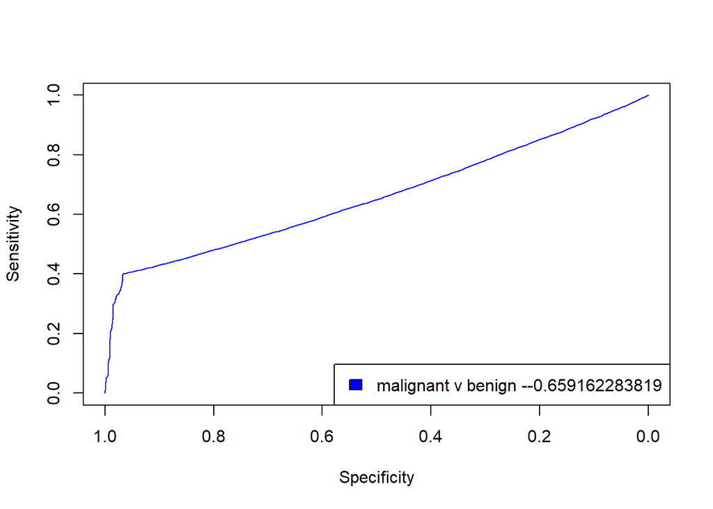

```r
#ROC curve for mitoses and cancer malignancy

plot(x = roc(predictor = BC_M$pred$malignant,
             response = BC_M$pred$obs)$specificities,
     y = roc(predictor = BC_M$pred$malignant,
             response = BC_M$pred$obs)$sensitivities,
     col= "blue", xlim = c(1, 0), type ="l", ylab = "Sensitivity",
     xlab = "Specificity")
legend("bottomright", legend = paste("malignant v benign --",
                                     roc(predictor = BC_M$pred$malignant,
                                         response = BC_M$pred$obs)$auc
, sep = ""), col = c("blue"), fill = c("blue"))
```

```r
#Confusion matri between mitoses class and cancer malignancy
M_predict_class <- predict(BC_M, newdata = test_clean)

#confusion matrix
confusionMatrix(M_predict_class,
                reference = test_clean$Class)
```

```
## Confusion Matrix and Statistics
##
##            Reference
## Prediction  benign malignant
##   benign       107        27
##   malignant      2        37
##
##                Accuracy : 0.8324
##                  95% CI : (0.7682, 0.8848)
##     No Information Rate : 0.6301
##     P-Value [Acc > NIR] : 4.361e-09
##
##                   Kappa : 0.6089
##
##  Mcnemar's Test P-Value : 8.324e-06
##
##             Sensitivity : 0.9817
##             Specificity : 0.5781
##          Pos Pred Value : 0.7985
##          Neg Pred Value : 0.9487
##              Prevalence : 0.6301
##          Detection Rate : 0.6185
##    Detection Prevalence : 0.7746
##       Balanced Accuracy : 0.7799
##
##        'Positive' Class : benign
##
```

```r
# Correlation test between log odds and mitoses

M_predict <- predict(BC_M,  newdata = test_clean, type = "prob")

# To convert from a probability to odds, divide the probability by one minus that probability. So if the probability is 10% or 0.10 , then the odds are 0.1/0.9 or ‘1 to 9’

nonlog_mito <- M_predict[,1] / (1 - M_predict[,1])
log_mito <- log(nonlog_mito)
cor.test(log_mito, test_clean$Mitoses)
```

[output not shown]

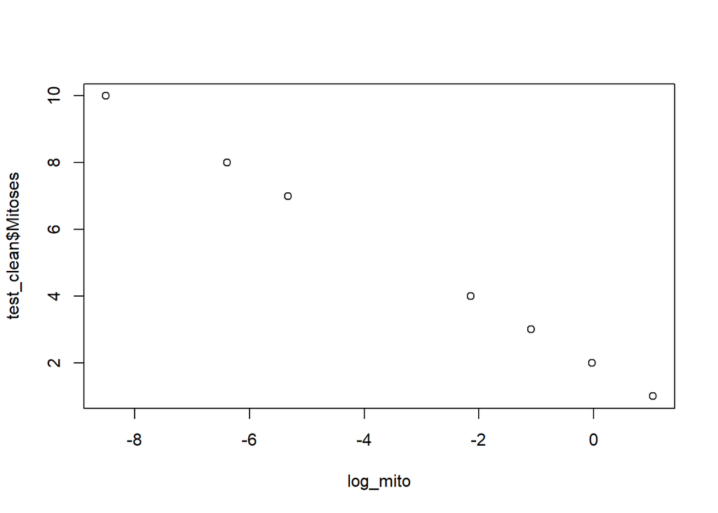

```r
plot(log_mito, test_clean$Mitoses)
```

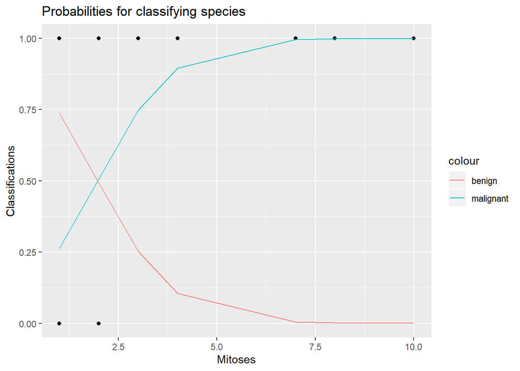

```r
# Probability plots of mitoses and cancer malignancy
M_predict_prob <- predict(BC_M,  newdata = test_clean, type="prob")

Mitoses_pred_prob_plot <- data.frame(Class_pred = M_predict_prob, Mitoses  = test_clean$Mitoses)


ggplot(data = test_clean) +
  geom_point(aes(x=Mitoses, y = Classifications)) +
  geom_line(data = Mitoses_pred_prob_plot, aes(x = Mitoses,
                                                y = Class_pred.benign, col =  "benign"))+
  geom_line(data = Mitoses_pred_prob_plot, aes(x = Mitoses,
                                                y = Class_pred.malignant, col = "malignant"))+
  ggtitle("Probabilities for classifying species")
```

References: https://sebastianraschka.com/Articles/2014_python_lda.html

https://towardsdatascience.com/building-a-multiple-linear-regression-model-and-assumptions-of-linear-regression-a-z-9769a6a0de42

http://www.statisticssolutions.com/wp-content/uploads/wp-post-to-pdf-enhanced-cache/1/assumptions-of-logistic-regression.pdf

https://machinelearningmastery.com/linear-discriminant-analysis-for-machine-learning/ , https://sebastianraschka.com/Articles/2014_python_lda.html

Other cool sites: https://www.countbayesie.com/blog/2019/6/12/logistic-regression-from-bayes-theorem https://colah.github.io/posts/2014-03-NN-Manifolds-Topology/